## Tarea 2

Programa Experto en Inteligencia Artificial con Python  
ML3003 - Deep Learning  
Estudiante: Natalia Bonilla Villalobos.  
**Redes Neuronales | Método del Percptrón**

# Menú

- Ejercicio 1
- Ejercicio 2
- Ejercicio 3
- Ejercicio 4

```python
# LIBRERÍAS ESTÁNDAR
import os                     # Manejo de archivos y rutas del sistema operativo
import warnings               # Control y supresión de advertencias

# MANEJO DE DATOS
import pandas as pd           # Manipulación y análisis de datos en DataFrames
import numpy as np            # Cálculo numérico y manejo de arreglos

# VISUALIZACIÓN
import matplotlib.pyplot as plt   # Gráficos básicos
import seaborn as sns             # Gráficos estadísticos más elaborados
from matplotlib import colors as mcolors  # Manejo de colores en gráficos

# SCIKIT-LEARN (Machine Learning)
from sklearn.model_selection import train_test_split   # División en entrenamiento y prueba
from sklearn.metrics import confusion_matrix, accuracy_score, recall_score, precision_score, f1_score, classification_report

from sklearn.pipeline import Pipeline                  # Encadenar preprocesamiento y modelo
from sklearn.compose import ColumnTransformer          # Aplicar transformaciones por columnas
from sklearn.preprocessing import OneHotEncoder        # Codificación de variables categóricas
from sklearn.preprocessing import StandardScaler       # Escalamiento de variables numéricas
from sklearn.preprocessing import LabelEncoder         # Codificar variable objetivo

from sklearn.neural_network import MLPClassifier       # Red neuronal tipo perceptrón multicapa

# DEEP LEARNING (TensorFlow / Keras)
from tensorflow.keras.models import Sequential         # Modelo secuencial de redes neuronales
from tensorflow.keras.layers import Dense              # Capas densas (fully connected)

# warnings.filterwarnings('ignore')  # Oculta warnings en la salida
```

# Ejercicio 1

[25 puntos] En este ejercicio se usará la tabla de datos `students_dropout.csv`. Este conjunto de datos contiene datos de una institución de educación superior sobre diversas variables relacionadas con los estudiantes de pregrado, para investigar el impacto de estos factores en la deserción de los estudiantes y el éxito académico. La tabla contiene 3630 filas y 13 columnas, las cuales se explican a continuación.

- `marital_status`: Estado Civil. (Categórica)
- `daytime_evening_attendance`: Si el estudiante asiste a clases durante el día o la noche. (Categórica)
- `educational_special_needs`: Si el estudiante tiene alguna necesidad educativa especial. (Categórica)
- `debtor`: Si el estudiante es deudor. (Categórica)
- `tuition_fees_up_to_date`: Si las tasas de matrícula del estudiante están al día. (Categórica)
- `gender`: Género del estudiante. (Categórica)
- `scholarship`: Si el estudiante tiene beca. (Categórica)
- `age_at_enrollment`: Edad del estudiante al momento de la inscripción. (Numérica)
- `international`: Si el estudiante es extranjero. (Categórica)
- `unemployment_rate`: Tasa de desempleo. (Numérica)
- `inflation`: Tasa de inación. (Numérica)
- `gdp`: PIB per cápita. (Numérica)
- `target`: Indica si el estudiante se graduó o abandonó. (Categórica, Variable a predecir)

Realice lo siguiente:

- a) Cargue en Python la tabla de datos.
- b) Usando el paquete MLPClassifier en Python genere modelos predictivos usando un 80% de los datos para la tabla aprendizaje y un 20% para la tabla testing. Genere al menos 2 modelos con configuraciones diferentes en los parámetros vistos en clase (hidden layer sizes, activation, solver).
- c) Usando el paquete tensorflow en Python genere modelos predictivos usando un 80% de los datos para tabla aprendizaje y un 20% para la tabla testing. Genere al menos 2 modelos con configuraciones diferentes en los parámetros vistos en clase (units, activation, optimizer).
- d) Para cada modelo obtenga los índices de precisión, compare e interprete los resultados.

↑ Volver al Menú

## Parte 1

- a) Cargue en Python la tabla de datos.

```python
df = pd.read_csv("students_dropout.csv")
df.head(3)
```

|  | marital_status | daytime_evening_attendance | educational_special_needs | debtor | tuition_fees_up_to_date | gender | scholarship_holder | age_at_enrollment | international | unemployment_rate | inflation_rate | gdp | target |
| --- | --- | --- | --- | --- | --- | --- | --- | --- | --- | --- | --- | --- | --- |
| 0 | Single | daytime | No | No | Yes | M | No | 20 | No | 10.8 | 1.4 | 1.74 | Dropout |
| 1 | Single | daytime | No | No | No | M | No | 19 | No | 13.9 | -0.3 | 0.79 | Graduate |
| 2 | Single | daytime | No | No | No | M | No | 19 | No | 10.8 | 1.4 | 1.74 | Dropout |

```python
df.info()
```

```
<class 'pandas.core.frame.DataFrame'>
RangeIndex: 3630 entries, 0 to 3629
Data columns (total 13 columns):
 #   Column                      Non-Null Count  Dtype
---  ------                      --------------  -----
 0   marital_status              3630 non-null   object
 1   daytime_evening_attendance  3630 non-null   object
 2   educational_special_needs   3630 non-null   object
 3   debtor                      3630 non-null   object
 4   tuition_fees_up_to_date     3630 non-null   object
 5   gender                      3630 non-null   object
 6   scholarship_holder          3630 non-null   object
 7   age_at_enrollment           3630 non-null   int64
 8   international               3630 non-null   object
 9   unemployment_rate           3630 non-null   float64
 10  inflation_rate              3630 non-null   float64
 11  gdp                         3630 non-null   float64
 12  target                      3630 non-null   object
dtypes: float64(3), int64(1), object(9)
memory usage: 368.8+ KB
```

```python
def asCategoryType(df, asCategory=True):
    df_copy = df.copy()
    target_var = df_copy['target']
    df_copy = df_copy.drop(columns=('target'))
    if asCategory:
        num_df = df_copy.select_dtypes(include=[np.number])
        cat_df = df_copy.select_dtypes(exclude=[np.number])

    if not cat_df.empty:
        for i in cat_df:
            cat_df[i] = cat_df[i].astype('category')
            df_copy = pd.concat([num_df, cat_df, target_var], axis=1)
    else:
        df_copy = pd.concat([num_df, cat_df], axis=1)

    return df_copy

df_cat = asCategoryType(df)
df_cat.info()
```

```
<class 'pandas.core.frame.DataFrame'>
RangeIndex: 3630 entries, 0 to 3629
Data columns (total 13 columns):
 #   Column                      Non-Null Count  Dtype
---  ------                      --------------  -----
 0   age_at_enrollment           3630 non-null   int64
 1   unemployment_rate           3630 non-null   float64
 2   inflation_rate              3630 non-null   float64
 3   gdp                         3630 non-null   float64
 4   marital_status              3630 non-null   category
 5   daytime_evening_attendance  3630 non-null   category
 6   educational_special_needs   3630 non-null   category
 7   debtor                      3630 non-null   category
 8   tuition_fees_up_to_date     3630 non-null   category
 9   gender                      3630 non-null   category
 10  scholarship_holder          3630 non-null   category
 11  international               3630 non-null   category
 12  target                      3630 non-null   object
dtypes: category(8), float64(3), int64(1), object(1)
memory usage: 171.3+ KB
```

```python
var_categoricas = "marital_status", "daytime_evening_attendance", "educational_special_needs", "debtor", "tuition_fees_up_to_date", "gender", "scholarship_holder", "international"
var_numericas = "age_at_enrollment", "unemployment_rate", "inflation_rate", "gdp"
```

```python
def distribucion_variable_predecir(data:pd.DataFrame, variable_predict:str):
  conteo     = data[variable_predict].value_counts()
  valores    = conteo.to_list()
  categorias = conteo.index.to_list()
  titulo     = "Distribución de la variable %s" % variable_predict

  fig, ax = plt.subplots()
  ax.bar(categorias, valores)

  ax.set_ylabel(variable_predict)
  ax.set_title(titulo)

  for i, valor in enumerate(valores):
    porc = round(valor / sum(valores) * 100, 2)
    text = str(valor) + "\n" + str(porc) + "%"
    ax.text(i, valor * 0.45, text, color='white', ha='center', fontsize=10)

  return(fig)
```

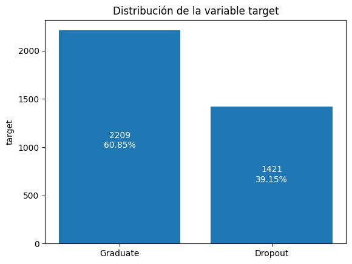

```python
fig = distribucion_variable_predecir(df, "target")
plt.show()
```

```python
def indices_general(MC, nombres = None):
  precision_global = np.sum(MC.diagonal()) / np.sum(MC)
  error_global     = 1 - precision_global
  precision_categoria  = pd.DataFrame(MC.diagonal()/np.sum(MC,axis = 1)).T
  if nombres!=None:
    precision_categoria.columns = nombres
    return {"Matriz de Confusión":MC,
            "Precisión Global":   precision_global,
            "Error Global":       error_global,
            "Precisión por categoría":precision_categoria}
```

## Indices

```python
# Version Simplificada de esta funcion que creó en otras clases
def clasification(matriz_confusion):
    precision_global = np.sum(matriz_confusion.diagonal()) / np.sum(matriz_confusion)
    error_global = 1 - precision_global
    precision_positiva, precision_negativa = matriz_confusion.diagonal()/np.sum(matriz_confusion,axis = 1)

    diccionario = {'precision_global ↑':precision_global,
                    'error_global ↓': error_global,
                    'precision_positiva ↑': precision_positiva,
                    'precision_negativa ↑': precision_negativa}

    return diccionario

# def clasification_v2(matriz_confusion):
#     VN = matriz_confusion[0][0]
#     FP = matriz_confusion[0][1]
#     FN = matriz_confusion[1][0]
#     VP = matriz_confusion[1][1]

#     precision_global = (VN+VP)/(VN+FP+FN+VP)
#     error_global = 1 - precision_global
#     precision_negativa = VP/(FN+VP)
#     precision_positiva = VN/(VN+FP)

#     diccionario = {'precision_global ↑':precision_global,
#                     'error_global ↓': error_global,
#                     'precision_positiva ↑': precision_positiva,
#                     'precision_negativa ↑': precision_negativa}

#     return diccionario
```

## Parte 2

- b) Usando el paquete `MLPClassifier` en Python genere modelos predictivos usando un 80% de los datos para la tabla aprendizaje y un 20% para la tabla testing. Genere al menos 2 modelos con configuraciones diferentes en los parámetros vistos en clase (`hidden_layer_sizes`, `activation`, `solver`).

### Division train/test y Preprocesamiento Sklearn

```python
X = df_cat.drop(columns=['target'])
y = df_cat['target'].to_numpy()
print("X:",X.head(3))
print('\ntarget =', y[:10])
```

```
X:    age_at_enrollment  unemployment_rate  inflation_rate   gdp marital_status  \
0                 20               10.8             1.4  1.74         Single
1                 19               13.9            -0.3  0.79         Single
2                 19               10.8             1.4  1.74         Single

  daytime_evening_attendance educational_special_needs debtor  \
0                    daytime                        No     No
1                    daytime                        No     No
2                    daytime                        No     No

  tuition_fees_up_to_date gender scholarship_holder international
0                     Yes      M                 No            No
1                      No      M                 No            No
2                      No      M                 No            No

target = ['Dropout' 'Graduate' 'Dropout' 'Graduate' 'Graduate' 'Graduate'
 'Graduate' 'Dropout' 'Graduate' 'Dropout']
```

```python
X_train, X_test, y_train, y_test = train_test_split(X, y, train_size=0.80) #80/20
```

```python
preprocesamiento = ColumnTransformer(
  transformers=[
    ('cat', OneHotEncoder(), var_categoricas),
    ('num', StandardScaler(), var_numericas)
  ]
)
```

### Modelo 1

- `hidden_layer_sizes`: $80, 40, 20$
- `activation`: $relu$ -> (identity, logistic, tanh y relu)
- `solver`: $adam$ -> (lbfgs, sgd y adam).
- `max_iter`: $8000$ -> (número de epochs). Por defecto el valor es de 200.

```python
modelo1 = Pipeline(steps=[
    ('preprocesador', preprocesamiento),
    ('clasificador', MLPClassifier(
        hidden_layer_sizes=(80, 40, 20),
        max_iter=8000,
        activation="relu",
        solver="adam",
        # random_state=0
    ))
])

modelo1.fit(X_train, y_train)
```

```
Pipeline(steps=[('preprocesador',
                 ColumnTransformer(transformers=[('cat', OneHotEncoder(),
                                                  ('marital_status',
                                                   'daytime_evening_attendance',
                                                   'educational_special_needs',
                                                   'debtor',
                                                   'tuition_fees_up_to_date',
                                                   'gender',
                                                   'scholarship_holder',
                                                   'international')),
                                                 ('num', StandardScaler(),
                                                  ('age_at_enrollment',
                                                   'unemployment_rate',
                                                   'inflation_rate',
                                                   'gdp'))])),
                ('clasificador',
                 MLPClassifier(hidden_layer_sizes=(80, 40, 20),
                               max_iter=8000))])
```

```python
pred1 = modelo1.predict(X_test)
pred1[:20]
```

```
array(['Graduate', 'Graduate', 'Graduate', 'Graduate', 'Dropout',
       'Graduate', 'Graduate', 'Graduate', 'Graduate', 'Graduate',
       'Graduate', 'Graduate', 'Dropout', 'Graduate', 'Graduate',
       'Dropout', 'Graduate', 'Graduate', 'Graduate', 'Dropout'],
      dtype='<U8')
```

```python
labels = ["Graduate", "Dropout"]
MC1 = confusion_matrix(y_test, pred1, labels=labels)

print(f'Matriz de Confusión:\n{MC1}')
modelo1_sk = clasification(MC1) # Guarda un diccionario
modelo1_sk_df = pd.DataFrame(list(modelo1_sk.items()), columns=['Metrics', 'Value'])
modelo1_sk_df['Modelo'] = 'Sklearn M1'
modelo1_sk_df
```

```
Matriz de Confusión:
[[396  39]
 [158 133]]
```

|  | Metrics | Value | Modelo |
| --- | --- | --- | --- |
| 0 | precision_global ↑ | 0.728650 | Sklearn M1 |
| 1 | error_global ↓ | 0.271350 | Sklearn M1 |
| 2 | precision_positiva ↑ | 0.910345 | Sklearn M1 |
| 3 | precision_negativa ↑ | 0.457045 | Sklearn M1 |

### Modelo 2

- `hidden_layer_sizes`: $100, 50, 10$.
- `activation`: $logistic$ -> (identity, logistic, tanh y relu).
- `solver`: $sgd$ -> (lbfgs, sgd y adam).
- `max_iter`: $8000$ -> (número de epochs). Por defecto el valor es de 200.

```python
modelo2 = Pipeline(steps=[
    ('preprocesador', preprocesamiento),
    ('clasificador', MLPClassifier(
        hidden_layer_sizes=(100, 50, 10),
        max_iter=8000,
        activation="logistic",
        solver="sgd",
        # random_state=0
    ))
])

modelo2.fit(X_train, y_train)

pred2 = modelo2.predict(X_test)

# Calculo de Indices
MC2 = confusion_matrix(y_test, pred2, labels=labels)

print(f'Matriz de Confusión:\n{MC2}')
modelo2_sk = clasification(MC2) # Guarda un diccionario
modelo2_sk_df = pd.DataFrame(list(modelo2_sk.items()), columns=['Metrics', 'Value'])
modelo2_sk_df['Modelo'] = 'Sklearn M2'
modelo2_sk_df
```

```
Matriz de Confusión:
[[435   0]
 [291   0]]
```

|  | Metrics | Value | Modelo |
| --- | --- | --- | --- |
| 0 | precision_global ↑ | 0.599174 | Sklearn M2 |
| 1 | error_global ↓ | 0.400826 | Sklearn M2 |
| 2 | precision_positiva ↑ | 1.000000 | Sklearn M2 |
| 3 | precision_negativa ↑ | 0.000000 | Sklearn M2 |

### Modelo 3

- `hidden_layer_sizes`: $200, 100, 50$.
- `activation`: $identity$ -> (identity, logistic, tanh y relu).
- `solver`: $lbfgs$ -> (lbfgs, sgd y adam).
- `max_iter`: $10000$ -> (número de epochs). Por defecto el valor es de 200.

```python
modelo3 = Pipeline(steps=[
    ('preprocesador', preprocesamiento),
    ('clasificador', MLPClassifier(
        hidden_layer_sizes=(200, 100, 50),
        max_iter=10000,
        activation="identity",
        solver="lbfgs",
        # random_state=0
    ))
])

modelo3.fit(X_train, y_train)

pred3 = modelo3.predict(X_test)

# Calculo de Indices
MC3 = confusion_matrix(y_test, pred3, labels=labels)

print(f'Matriz de Confusión:\n{MC3}')
modelo3_sk = clasification(MC3) # Guarda un diccionario
modelo3_sk_df = pd.DataFrame(list(modelo3_sk.items()), columns=['Metrics', 'Value'])
modelo3_sk_df['Modelo'] = 'Sklearn M3'
modelo3_sk_df
```

```
Matriz de Confusión:
[[390  45]
 [139 152]]
```

|  | Metrics | Value | Modelo |
| --- | --- | --- | --- |
| 0 | precision_global ↑ | 0.746556 | Sklearn M3 |
| 1 | error_global ↓ | 0.253444 | Sklearn M3 |
| 2 | precision_positiva ↑ | 0.896552 | Sklearn M3 |
| 3 | precision_negativa ↑ | 0.522337 | Sklearn M3 |

### Modelo 4

- `hidden_layer_sizes`: $30, 10, 3$.
- `activation`: $tanh$ -> (identity, logistic, tanh y relu).
- `solver`: $adam$ -> (lbfgs, sgd y adam).
- `max_iter`: $300$ -> (número de epochs). Por defecto el valor es de 200.

```python
modelo4 = Pipeline(steps=[
    ('preprocesador', preprocesamiento),
    ('clasificador', MLPClassifier(
        hidden_layer_sizes=(30, 10, 3),
        max_iter=300,
        activation="tanh",
        solver="adam",
        # random_state=0
    ))
])

modelo4.fit(X_train, y_train)

pred4 = modelo4.predict(X_test)

# Calculo de Indices
MC4 = confusion_matrix(y_test, pred4, labels=labels)

print(f'Matriz de Confusión:\n{MC4}')
modelo4_sk = clasification(MC4) # Guarda un diccionario
modelo4_sk_df = pd.DataFrame(list(modelo4_sk.items()), columns=['Metrics', 'Value'])
modelo4_sk_df['Modelo'] = 'Sklearn M4'
modelo4_sk_df
```

```
Matriz de Confusión:
[[365  70]
 [115 176]]
```

|  | Metrics | Value | Modelo |
| --- | --- | --- | --- |
| 0 | precision_global ↑ | 0.745179 | Sklearn M4 |
| 1 | error_global ↓ | 0.254821 | Sklearn M4 |
| 2 | precision_positiva ↑ | 0.839080 | Sklearn M4 |
| 3 | precision_negativa ↑ | 0.604811 | Sklearn M4 |

## Parte 3

- c) Usando el paquete `tensorflow` en Python genere modelos predictivos usando un 80% de los datos para tabla aprendizaje y un 20% para la tabla testing. Genere al menos 2 modelos con configuraciones diferentes en los parámetros vistos en clase (`units`, `activation`, `optimizer`).

### Division train/test y Preprocesamiento Tensorflow

```python
df_encoder = df_cat.copy()
df_encoder = df_encoder.iloc[:, 0:12]  # Se excluye target
# df_encoder = OneHotEncoder([])
encoder = LabelEncoder()

for var in var_categoricas:
    df_encoder[var] = encoder.fit_transform(df_encoder[var])
    df_encoder[var] = df_encoder[var].astype('category')

df_encoder.head(3)
print(df_encoder.info())
```

```
<class 'pandas.core.frame.DataFrame'>
RangeIndex: 3630 entries, 0 to 3629
Data columns (total 12 columns):
 #   Column                      Non-Null Count  Dtype
---  ------                      --------------  -----
 0   age_at_enrollment           3630 non-null   int64
 1   unemployment_rate           3630 non-null   float64
 2   inflation_rate              3630 non-null   float64
 3   gdp                         3630 non-null   float64
 4   marital_status              3630 non-null   category
 5   daytime_evening_attendance  3630 non-null   category
 6   educational_special_needs   3630 non-null   category
 7   debtor                      3630 non-null   category
 8   tuition_fees_up_to_date     3630 non-null   category
 9   gender                      3630 non-null   category
 10  scholarship_holder          3630 non-null   category
 11  international               3630 non-null   category
dtypes: category(8), float64(3), int64(1)
memory usage: 143.0 KB
None
```

```python
X = np.array(df_encoder)

y = df_cat['target'].to_numpy().ravel()

# encoder = LabelEncoder()
y = encoder.fit_transform(y)

print("X =",X[:10])
print('\ntarget =', y[:10])
encoder.classes_
```

```
X = [[20.   10.8   1.4   1.74  4.    0.    0.    0.    1.    1.    0.    0.  ]
 [19.   13.9  -0.3   0.79  4.    0.    0.    0.    0.    1.    0.    0.  ]
 [19.   10.8   1.4   1.74  4.    0.    0.    0.    0.    1.    0.    0.  ]
 [20.    9.4  -0.8  -3.12  4.    0.    0.    0.    1.    0.    0.    0.  ]
 [45.   13.9  -0.3   0.79  3.    1.    0.    0.    1.    0.    0.    0.  ]
 [50.   16.2   0.3  -0.92  3.    1.    0.    1.    1.    1.    0.    0.  ]
 [18.   15.5   2.8  -4.06  4.    0.    0.    0.    1.    0.    1.    0.  ]
 [22.   15.5   2.8  -4.06  4.    0.    0.    0.    0.    1.    0.    0.  ]
 [21.   16.2   0.3  -0.92  4.    0.    0.    0.    1.    0.    1.    1.  ]
 [18.    8.9   1.4   3.51  4.    0.    0.    1.    0.    0.    0.    0.  ]]

target = [0 1 0 1 1 1 1 0 1 0]
```

```
array(['Dropout', 'Graduate'], dtype=object)
```

```python
X_train, X_test, y_train, y_test = train_test_split(X, y, train_size=0.80) #80/20

preprocesamiento = ColumnTransformer(
  transformers=[
    ('cat', OneHotEncoder(), var_categoricas),
    ('num', StandardScaler(), var_numericas)
  ]
)
```

### Modelo 1

Para agregar una capa debemos utilizar la función Dense. Luego podemos definir los siguientes parámetros:

- `units`: $10, 5$ -> Define la cantidad de nodos.
- `activation`: $relu, sigmoid$ -> Define la función de activación a utilizar.  
  Estos pueden ser: deserialize, elu, exponential, gelu, get, hard_sigmoid, linear, mish, relu, selu, serialize, sigmoid, softmax, softplus, softsign, swish y tanh.

Al final siempre debemos configurar el método compile. Los parámetros pueden ser:

```python
# Instanciamos nuestra base. Se puede ver como una caja vacía donde vamos añadiendo elementos.
modelo_nn  = Sequential()
# Capa de entrada y primera capa oculta
modelo_nn.add(Dense(units = 10, activation = 'relu', input_shape=(X_train.shape[1],)))
# Segunda Capa oculta
modelo_nn.add(Dense(units = 5, activation = 'relu'))

# Capa de salida.
# units = 1 debido a que son 2 clases a predecir
modelo_nn.add(Dense(units = 1, activation = 'sigmoid'))

# Configuramos el modelo
# Para los parámetros
modelo_nn.compile(
  optimizer = 'adam', loss = 'binary_crossentropy',
  metrics = ['accuracy'])

"""
  batch_size: Número de muestras que se procesan antes de que el modelo actualice sus parámetros.
  epochs: Define el número de veces que el algoritmo de aprendizaje recorrerá todo el conjunto de datos de entrenamiento.
"""
modelo_nn.fit(X_train, y_train, epochs = 50, batch_size = 16, verbose = 0)
```

```
<keras.src.callbacks.history.History at 0x20f57df76a0>
```

```python
loss, accu = modelo_nn.evaluate(X_test, y_test, verbose = 1)
accu
```

```
23/23 ━━━━━━━━━━━━━━━━━━━━ 0s 1ms/step - accuracy: 0.7328 - loss: 0.5387
```

```
0.7327823638916016
```

```python
pred = modelo_nn.predict(X_test, verbose = 0)
pred = np.argmax(pred, axis = -1)
pred[:9]
```

```
array([0, 0, 0, 0, 0, 0, 0, 0, 0])
```

```python
pred = encoder.inverse_transform(pred)
pred[:9]
```

```
array(['Dropout', 'Dropout', 'Dropout', 'Dropout', 'Dropout', 'Dropout',
       'Dropout', 'Dropout', 'Dropout'], dtype=object)
```

```python
y_test_classes = encoder.inverse_transform(y_test)

# Calculo de Indices
MC1 = confusion_matrix(y_test_classes, pred, labels = encoder.classes_)

print(f'Matriz de Confusión:\n{MC1}')
modelo1_tf = clasification(MC1) # Guarda un diccionario
modelo1_tf_df = pd.DataFrame(list(modelo1_tf.items()), columns=['Metrics', 'Value'])
modelo1_tf_df['Modelo'] = 'TensorFlow M1'
modelo1_tf_df
```

```
Matriz de Confusión:
[[287   0]
 [439   0]]
```

|  | Metrics | Value | Modelo |
| --- | --- | --- | --- |
| 0 | precision_global ↑ | 0.395317 | TensorFlow M1 |
| 1 | error_global ↓ | 0.604683 | TensorFlow M1 |
| 2 | precision_positiva ↑ | 1.000000 | TensorFlow M1 |
| 3 | precision_negativa ↑ | 0.000000 | TensorFlow M1 |

### Modelo 2

Para agregar una capa debemos utilizar la función Dense. Luego podemos definir los siguientes parámetros:

- `units`: $36, 16, 8, 1$
- `activation`: $tanh, relu, sigmoid$ -> deserialize, elu, exponential, gelu, get, hard_sigmoid, linear, mish, relu, selu, serialize, sigmoid, softmax, softplus, softsign, swish y tanh.

Al final siempre debemos configurar el método compile. Los parámetros pueden ser:

- `optimizer`: $nadam$ -> adadelta, adafactor, adagrad, adam, adamW, adamax, ftrl, lion, nadam, optimizer y sgd.
- `loss`: $binary_ crossentropy$ -> binary_crossentropy (cuando el problema es de clasificación de 2 categorías), sparse_categorical_crossentropy (cuando el problema es de clasificación de más de 2 categorías) y mean_squared_error (cuando el problema es de regresión).
- `metrics`: $accuracy$ -> Define la metrica a utilizar para evaluar el modelo. Estos pueden ser: accuracy (precisión de acierto de las categorías) y mean_squared_error (mide la raíz de error cuadratico medio).

```python
# Instanciamos nuestra base. Se puede ver como una caja vacía donde vamos añadiendo elementos.
modelo_nn2  = Sequential()
# Capa de entrada y primera capa oculta
modelo_nn2.add(Dense(units = 36, activation = 'tanh', input_shape=(X_train.shape[1],)))
# Segunda Capa oculta
modelo_nn2.add(Dense(units = 16, activation = 'tanh'))
# Tercera Capa oculta
modelo_nn2.add(Dense(units = 8, activation = 'relu'))

# Capa de salida.
# units = 1 debido a que son 2 clases a predecir
modelo_nn2.add(Dense(units = 1, activation = 'sigmoid'))

# Configuramos el modelo
# Para los parámetros
modelo_nn2.compile(
  optimizer = 'nadam', loss = 'binary_crossentropy',
  metrics = ['accuracy'])

"""
  batch_size: Número de muestras que se procesan antes de que el modelo actualice sus parámetros.
  epochs: Define el número de veces que el algoritmo de aprendizaje recorrerá todo el conjunto de datos de entrenamiento.
"""
modelo_nn2.fit(X_train, y_train, epochs = 100, batch_size = 16, verbose = 0)

loss, accu = modelo_nn2.evaluate(X_test, y_test, verbose = 0)
print("accu: ",accu)

pred = modelo_nn2.predict(X_test, verbose = 0)
pred = np.argmax(pred, axis = -1)
# pred[:9]

pred = encoder.inverse_transform(pred)
# pred[:9]

y_test_classes = encoder.inverse_transform(y_test)

# Calculo de Indices
MC2 = confusion_matrix(y_test_classes, pred, labels = encoder.classes_)

print(f'Matriz de Confusión:\n{MC2}')
modelo2_tf = clasification(MC2) # Guarda un diccionario
modelo2_tf_df = pd.DataFrame(list(modelo2_tf.items()), columns=['Metrics', 'Value'])
modelo2_tf_df['Modelo'] = 'TensorFlow M2'
modelo2_tf_df
```

```
accu:  0.7286501526832581
Matriz de Confusión:
[[287   0]
 [439   0]]
```

|  | Metrics | Value | Modelo |
| --- | --- | --- | --- |
| 0 | precision_global ↑ | 0.395317 | TensorFlow M2 |
| 1 | error_global ↓ | 0.604683 | TensorFlow M2 |
| 2 | precision_positiva ↑ | 1.000000 | TensorFlow M2 |
| 3 | precision_negativa ↑ | 0.000000 | TensorFlow M2 |

### Modelo 3

Para agregar una capa debemos utilizar la función Dense. Luego podemos definir los siguientes parámetros:

- `units`: $16, 1$
- `activation`: $relu, sigmoid$ -> deserialize, elu, exponential, gelu, get, hard_sigmoid, linear, mish, relu, selu, serialize, sigmoid, softmax, softplus, softsign, swish y tanh.

Al final siempre debemos configurar el método compile. Los parámetros pueden ser:

- `optimizer`: $adam$ -> adadelta, adafactor, adagrad, adam, adamW, adamax, ftrl, lion, nadam, optimizer y sgd.
- `loss`: $binary_crossentropy$ -> binary_crossentropy (cuando el problema es de clasificación de 2 categorías), sparse_categorical_crossentropy (cuando el problema es de clasificación de más de 2 categorías) y mean_squared_error (cuando el problema es de regresión).
- `metrics`: $accuracy$ -> Define la metrica a utilizar para evaluar el modelo. Estos pueden ser: accuracy (precisión de acierto de las categorías) y mean_squared_error (mide la raíz de error cuadratico medio).

```python
# Instanciamos nuestra base. Se puede ver como una caja vacía donde vamos añadiendo elementos.
modelo_nn3  = Sequential()
# Capa de entrada y primera capa oculta
modelo_nn3.add(Dense(units = 16, activation = 'relu', input_shape=(X_train.shape[1],)))
# Segunda Capa oculta
# modelo_nn3.add(Dense(units = 16, activation = 'relu'))
# # Tercera Capa oculta
# modelo_nn3.add(Dense(units = 8, activation = 'softmax'))

# Capa de salida.
# units = 1 debido a que son 2 clases a predecir
modelo_nn3.add(Dense(units = 1, activation = 'sigmoid'))

# Configuramos el modelo
# Para los parámetros
modelo_nn3.compile(
  optimizer = 'adam', loss = 'binary_crossentropy',
  metrics = ['accuracy'])

"""
  batch_size: Número de muestras que se procesan antes de que el modelo actualice sus parámetros.
  epochs: Define el número de veces que el algoritmo de aprendizaje recorrerá todo el conjunto de datos de entrenamiento.
"""
modelo_nn3.fit(X_train, y_train, epochs = 100, batch_size = 32, verbose = 0)

loss, accu = modelo_nn3.evaluate(X_test, y_test, verbose = 0)
print("accu: ", accu)

pred = modelo_nn3.predict(X_test, verbose = 0)
pred = np.argmax(pred, axis = -1)
# pred[:9]

pred = encoder.inverse_transform(pred)
# pred[:9]

y_test_classes = encoder.inverse_transform(y_test)

# Calculo de Indices
MC3 = confusion_matrix(y_test_classes, pred, labels = encoder.classes_)

print(f'Matriz de Confusión:\n{MC3}')
modelo3_tf = clasification(MC3) # Guarda un diccionario
modelo3_tf_df = pd.DataFrame(list(modelo3_tf.items()), columns=['Metrics', 'Value'])
modelo3_tf_df['Modelo'] = 'TensorFlow M3'
modelo3_tf_df
```

```
accu:  0.7396694421768188
Matriz de Confusión:
[[287   0]
 [439   0]]
```

|  | Metrics | Value | Modelo |
| --- | --- | --- | --- |
| 0 | precision_global ↑ | 0.395317 | TensorFlow M3 |
| 1 | error_global ↓ | 0.604683 | TensorFlow M3 |
| 2 | precision_positiva ↑ | 1.000000 | TensorFlow M3 |
| 3 | precision_negativa ↑ | 0.000000 | TensorFlow M3 |

## Parte 4

- d) Para cada modelo obtenga los índices de precisión, compare e interprete los resultados.

```python
todos_los_modelos = pd.concat([modelo1_sk_df, modelo2_sk_df, modelo3_sk_df, modelo4_sk_df, modelo1_tf_df, modelo2_tf_df, modelo3_tf_df])
# pd.pivot_table(all_metrics, index='Modelo Predictivo', columns=['Metrics'], values='Value', fill_value=0)
# todos_los_modelos


metricas_pivot = pd.pivot(todos_los_modelos, index='Modelo', columns=['Metrics'], values='Value').sort_values('precision_negativa ↑', ascending=False)
metricas_pivot
```

| Metrics Modelo | error_global ↓ | precision_global ↑ | precision_negativa ↑ | precision_positiva ↑ |
| --- | --- | --- | --- | --- |
| Sklearn M4 | 0.254821 | 0.745179 | 0.604811 | 0.839080 |
| Sklearn M3 | 0.253444 | 0.746556 | 0.522337 | 0.896552 |
| Sklearn M1 | 0.271350 | 0.728650 | 0.457045 | 0.910345 |
| Sklearn M2 | 0.400826 | 0.599174 | 0.000000 | 1.000000 |
| TensorFlow M1 | 0.604683 | 0.395317 | 0.000000 | 1.000000 |
| TensorFlow M2 | 0.604683 | 0.395317 | 0.000000 | 1.000000 |
| TensorFlow M3 | 0.604683 | 0.395317 | 0.000000 | 1.000000 |

Existe un desablance claro entre 'Graduate' (60.85%) y 'Dropout' (39.15%) y ninguna combinación de los parámetros usados en los modelos generados entre Sklearn y Tensorflow, lograron un balance significativo entre PP y PN.

# Ejercicio 2

[25 puntos] En este ejercicio vamos a predecir números escritos a mano (Hand Written Digit Recognition), la tabla de aprendizaje está en el archivo `ZipDataTrainCod.csv` y la tabla de testing está en el archivo `ZipDataTestCod.csv`. En la figura siguiente se ilustran los datos:

[figure not shown]

Los datos de este ejemplo vienen de los códigos postales escritos a mano en sobres del correo postal de EE.UU. Las imágenes son de $16 x 16$ en escala de grises, cada pixel va de intensidad de $-1$ a $1$ (de blanco a negro). Las imágenes se han normalizado para tener aproximadamente el mismo tamaño y orientación. La tarea consiste en predecir, a partir de la matriz de $16 x 16$ de intensidades de cada pixel, la identidad de cada imagen $(0, 1, ..., 9)$ de forma rápida y precisa. Si es lo suficientemente precisa, el algoritmo resultante se utiliza como parte de un procedimiento de selección automática para sobres. Este es un problema de **clasificación** para el cual la tasa de error debe mantenerse muy baja para evitar la mala dirección de correo. La columna 1 tiene la variable a predecir `Número` codificada como sigue: $0='cero'; 1='uno'; 2='dos'; 3='tres'; 4='cuatro'; 5='cinco';6='seis'; 7='siete'; 8='ocho'$ y $9='nueve'$, las demás columnas son las variables predictivas, además cada fila de la tabla representa un bloque $16 x 16$ por lo que la matriz tiene 256 variables predictoras.

- a) Usando el paquete `MLPClassifier` en **Python** genere un modelo predictivo de redes neuronales para estos datos. Utilice los siguientes parámetros:
  - `hidden_layer_sizes` = (250, 100, 50, 25)
  - `max_iter` = 50000
  - `activation` = 'relu'
  - `solver` = 'adam'
  - `random_state` = 0

  Interprete los resultados.
- b) Genere un modelo de redes neuronales con los mismos parámetros del ítem anterior, pero esta vez reemplace cada bloque 4 x 4 de píxeles por su promedio. Mejora la predicción? Qué ventaja tiene estos datos respecto a los anteriores? Recuerde que cada bloque 16x16 está representado por una fila en las matrices de aprendizaje y testing. Despliegue la matriz de confusión resultante. La matriz de confusión obtenida debería ser igual o muy similar a ésta:

[figure not shown]

  No es necesario que las categorías se muestren en orden.
- c) Repita el item anterior pero esta vez reemplace cada bloque 4x4 de píxeles por el máximo. Mejoran resultados respecto a usar el promedio de cada bloque?

↑ Volver al Menú

## Carga de datos

```python
df_trainCod = pd.read_csv('ZipDataTrainCod.csv', delimiter=';')
df_trainCod
```

|  | Numero | V2 | V3 | V4 | V5 | V6 | V7 | V8 | V9 | V10 | ... | V248 | V249 | V250 | V251 | V252 | V253 | V254 | V255 | V256 | V257 |
| --- | --- | --- | --- | --- | --- | --- | --- | --- | --- | --- | --- | --- | --- | --- | --- | --- | --- | --- | --- | --- | --- |
| 0 | seis | -1.0 | -1.0 | -1.0 | -1.000 | -1.000 | -1.000 | -1.000 | -0.631 | 0.862 | ... | 0.304 | 0.823 | 1.000 | 0.482 | -0.474 | -0.991 | -1.000 | -1.000 | -1.000 | -1.0 |
| 1 | cinco | -1.0 | -1.0 | -1.0 | -0.813 | -0.671 | -0.809 | -0.887 | -0.671 | -0.853 | ... | -0.671 | -0.671 | -0.033 | 0.761 | 0.762 | 0.126 | -0.095 | -0.671 | -0.828 | -1.0 |
| 2 | cuatro | -1.0 | -1.0 | -1.0 | -1.000 | -1.000 | -1.000 | -1.000 | -1.000 | -1.000 | ... | -1.000 | -1.000 | -1.000 | -0.109 | 1.000 | -0.179 | -1.000 | -1.000 | -1.000 | -1.0 |
| 3 | siete | -1.0 | -1.0 | -1.0 | -1.000 | -1.000 | -0.273 | 0.684 | 0.960 | 0.450 | ... | -0.318 | 1.000 | 0.536 | -0.987 | -1.000 | -1.000 | -1.000 | -1.000 | -1.000 | -1.0 |
| 4 | tres | -1.0 | -1.0 | -1.0 | -1.000 | -1.000 | -0.928 | -0.204 | 0.751 | 0.466 | ... | 0.466 | 0.639 | 1.000 | 1.000 | 0.791 | 0.439 | -0.199 | -0.883 | -1.000 | -1.0 |
| ... | ... | ... | ... | ... | ... | ... | ... | ... | ... | ... | ... | ... | ... | ... | ... | ... | ... | ... | ... | ... | ... |
| 7286 | tres | -1.0 | -1.0 | -1.0 | -0.988 | -0.527 | -0.208 | 0.620 | 1.000 | 0.467 | ... | -0.116 | 0.899 | 0.416 | -0.510 | -1.000 | -1.000 | -1.000 | -1.000 | -1.000 | -1.0 |
| 7287 | tres | -1.0 | -1.0 | -1.0 | -0.990 | 0.708 | 0.557 | 0.347 | -0.107 | -0.758 | ... | 0.697 | 0.636 | 0.167 | -0.968 | -1.000 | -1.000 | -1.000 | -1.000 | -1.000 | -1.0 |
| 7288 | tres | -1.0 | -1.0 | -1.0 | -0.783 | -0.984 | -0.827 | 0.068 | 1.000 | 1.000 | ... | 0.805 | 1.000 | 1.000 | 0.727 | -0.342 | -0.933 | -1.000 | -1.000 | -1.000 | -1.0 |
| 7289 | cero | -1.0 | -1.0 | -1.0 | -1.000 | -1.000 | -0.549 | 0.463 | 0.999 | 0.999 | ... | -0.231 | 0.621 | 0.999 | -0.042 | -0.231 | -0.687 | -1.000 | -1.000 | -1.000 | -1.0 |
| 7290 | uno | -1.0 | -1.0 | -1.0 | -1.000 | -1.000 | -0.108 | 1.000 | 0.616 | -0.867 | ... | -0.634 | 0.803 | 0.589 | -0.907 | -1.000 | -1.000 | -1.000 | -1.000 | -1.000 | -1.0 |

7291 rows × 257 columns

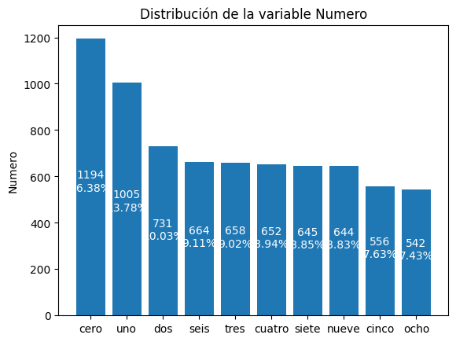

```python
fig = distribucion_variable_predecir(df_trainCod, "Numero")
plt.show()
```

```python
X_trainCode = df_trainCod.drop(columns=['Numero'])
y_trainCode = df_trainCod['Numero']
```

```python
train_columns = X_trainCode.columns
# train_columns
```

```python
df_testCod = pd.read_csv('ZipDatatestCod.csv', delimiter=';')
df_testCod
```

|  | Numero | V2 | V3 | V4 | V5 | V6 | V7 | V8 | V9 | V10 | ... | V248 | V249 | V250 | V251 | V252 | V253 | V254 | V255 | V256 | V257 |
| --- | --- | --- | --- | --- | --- | --- | --- | --- | --- | --- | --- | --- | --- | --- | --- | --- | --- | --- | --- | --- | --- |
| 0 | nueve | -1.0 | -1.0 | -1.0 | -1.000 | -1.000 | -0.948 | -0.561 | 0.148 | 0.384 | ... | -1.000 | -0.908 | 0.430 | 0.622 | -0.973 | -1.000 | -1.0 | -1.0 | -1.0 | -1.0 |
| 1 | seis | -1.0 | -1.0 | -1.0 | -1.000 | -1.000 | -1.000 | -1.000 | -1.000 | -1.000 | ... | -1.000 | -1.000 | -1.000 | -1.000 | -1.000 | -1.000 | -1.0 | -1.0 | -1.0 | -1.0 |
| 2 | tres | -1.0 | -1.0 | -1.0 | -0.593 | 0.700 | 1.000 | 1.000 | 1.000 | 1.000 | ... | 1.000 | 0.717 | 0.333 | 0.162 | -0.393 | -1.000 | -1.0 | -1.0 | -1.0 | -1.0 |
| 3 | seis | -1.0 | -1.0 | -1.0 | -1.000 | -1.000 | -1.000 | -1.000 | -1.000 | -1.000 | ... | -1.000 | -1.000 | -1.000 | -1.000 | -1.000 | -1.000 | -1.0 | -1.0 | -1.0 | -1.0 |
| 4 | seis | -1.0 | -1.0 | -1.0 | -1.000 | -1.000 | -1.000 | -1.000 | -0.858 | -0.106 | ... | 0.901 | 0.901 | 0.901 | 0.290 | -0.369 | -0.867 | -1.0 | -1.0 | -1.0 | -1.0 |
| ... | ... | ... | ... | ... | ... | ... | ... | ... | ... | ... | ... | ... | ... | ... | ... | ... | ... | ... | ... | ... | ... |
| 2002 | tres | -1.0 | -1.0 | -1.0 | -1.000 | -1.000 | -0.417 | 0.814 | 1.000 | 0.775 | ... | 1.000 | 1.000 | 0.554 | 0.184 | -0.484 | -1.000 | -1.0 | -1.0 | -1.0 | -1.0 |
| 2003 | nueve | -1.0 | -1.0 | -1.0 | -1.000 | -1.000 | -1.000 | -0.855 | 0.209 | 0.941 | ... | -1.000 | 0.319 | 1.000 | 0.056 | -1.000 | -1.000 | -1.0 | -1.0 | -1.0 | -1.0 |
| 2004 | cuatro | -1.0 | -1.0 | -1.0 | -1.000 | -0.031 | 0.752 | -0.431 | -1.000 | -1.000 | ... | 1.000 | 0.928 | -0.393 | -1.000 | -1.000 | -1.000 | -1.0 | -1.0 | -1.0 | -1.0 |
| 2005 | cero | -1.0 | -1.0 | -1.0 | -1.000 | -0.534 | 0.578 | 1.000 | 0.301 | -0.328 | ... | 1.000 | 0.430 | 0.200 | -0.061 | -0.975 | -1.000 | -1.0 | -1.0 | -1.0 | -1.0 |
| 2006 | uno | -1.0 | -1.0 | -1.0 | -1.000 | -1.000 | -1.000 | -1.000 | 0.399 | 0.949 | ... | -1.000 | -0.505 | 0.907 | 0.655 | -0.950 | -1.000 | -1.0 | -1.0 | -1.0 | -1.0 |

2007 rows × 257 columns

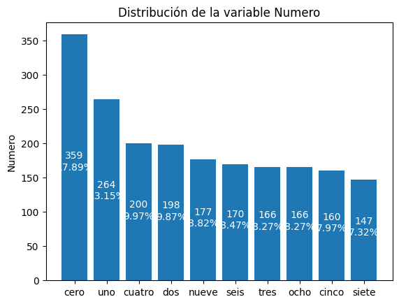

```python
fig = distribucion_variable_predecir(df_testCod, "Numero")
plt.show()
```

```python
X_testCode = df_testCod.drop(columns=['Numero'])
y_testCode = df_testCod['Numero']
```

```python
test_columns = X_testCode.columns
# test_columns
```

```python
# labels = df_testCod['Numero'].unique()
labels = ['cero','uno','dos','tres','cuatro', 'cinco','seis','siete','ocho','nueve']
```

## Parte 1

- a) Usando el paquete `MLPClassifier` en **Python** genere un modelo predictivo de redes neuronales para estos datos. Utilice los siguientes parámetros:
  - `hidden_layer_sizes` = (250, 100, 50, 25)
  - `max_iter` = 50000
  - `activation` = 'relu'
  - `solver` = 'adam'
  - `random_state` = 0

  Interprete los resultados.

```python
nnet = MLPClassifier(
              hidden_layer_sizes = (250, 100, 50, 25), # 3 capas ocultas.
              activation = "relu", # Función de activación relu
              solver = "adam", # Solucionador adam
              max_iter = 50000, # Iteraciones máximas
              random_state = 0
              )

nnet.fit(X_trainCode, y_trainCode)
```

```
MLPClassifier(hidden_layer_sizes=(250, 100, 50, 25), max_iter=50000,
              random_state=0)
```

```python
pred = nnet.predict(X_testCode)
pred[:10]
```

```
array(['nueve', 'seis', 'tres', 'seis', 'seis', 'cero', 'cero', 'cero',
       'seis', 'nueve'], dtype='<U6')
```

```python
# labels = ["Si", "No"]
MC = confusion_matrix(y_testCode, pred, labels=labels)

print(f'Matriz de Confusión:\n{MC}')
# MC_df = pd.DataFrame(MC, index=labels, columns=labels)
# MC_df

# modelo = impresion_indces(MC) # Guarda un diccionario
# modelo = pd.DataFrame(list(modelo.items()), columns=['Metrics', 'Value'])
# modelo
```

```
Matriz de Confusión:
[[352   0   2   0   3   0   1   0   0   1]
 [  0 253   1   1   4   0   3   0   1   1]
 [  3   0 181   3   2   0   1   2   6   0]
 [  1   0   3 149   0   9   0   0   4   0]
 [  1   2   2   0 187   2   2   0   0   4]
 [  3   0   1   5   0 147   0   0   1   3]
 [  0   0   3   0   2   1 163   0   1   0]
 [  0   0   1   0   7   0   0 136   1   2]
 [  4   0   2   4   3   1   0   1 150   1]
 [  0   0   0   0   6   1   0   1   0 169]]
```

```python
MC_df = pd.DataFrame(MC, index=labels, columns=labels)
MC_df
```

|  | cero | uno | dos | tres | cuatro | cinco | seis | siete | ocho | nueve |
| --- | --- | --- | --- | --- | --- | --- | --- | --- | --- | --- |
| cero | 352 | 0 | 2 | 0 | 3 | 0 | 1 | 0 | 0 | 1 |
| uno | 0 | 253 | 1 | 1 | 4 | 0 | 3 | 0 | 1 | 1 |
| dos | 3 | 0 | 181 | 3 | 2 | 0 | 1 | 2 | 6 | 0 |
| tres | 1 | 0 | 3 | 149 | 0 | 9 | 0 | 0 | 4 | 0 |
| cuatro | 1 | 2 | 2 | 0 | 187 | 2 | 2 | 0 | 0 | 4 |
| cinco | 3 | 0 | 1 | 5 | 0 | 147 | 0 | 0 | 1 | 3 |
| seis | 0 | 0 | 3 | 0 | 2 | 1 | 163 | 0 | 1 | 0 |
| siete | 0 | 0 | 1 | 0 | 7 | 0 | 0 | 136 | 1 | 2 |
| ocho | 4 | 0 | 2 | 4 | 3 | 1 | 0 | 1 | 150 | 1 |
| nueve | 0 | 0 | 0 | 0 | 6 | 1 | 0 | 1 | 0 | 169 |

Es interensate como es que en determinado numero se confunde más que cuando se evalúa alrevez.

## Parte 2

- b) Genere un modelo de redes neuronales con los mismos parámetros del ítem anterior, pero esta vez reemplace cada bloque 4 x 4 de píxeles por su promedio. Mejora la predicción? Qué ventaja tiene estos datos respecto a los anteriores? Recuerde que cada bloque 16x16 está representado por una fila en las matrices de aprendizaje y testing. Despliegue la matriz de confusión resultante. La matriz de confusión obtenida debería ser igual o muy similar a ésta:

[figure not shown]

  No es necesario que las categorías se muestren en orden.

```python
# primera imagen
# img = X_trainCode.iloc[0].values

# # pasada a matriz 16x16
# img_matrix = img.reshape(16,16)
# # img_matrix
# img_matrix_df = pd.DataFrame(img_matrix)
# img_matrix_df

# # Bloque 1
# bloque1 = img_matrix[0:4, 0:4]
# prom1 = bloque1.mean()

# # Bloque 2
# bloque2 = img_matrix[0:4, 4:8]
# prom2 = bloque2.mean()

# # Bloque 3
# bloque3 = img_matrix[0:4, 8:12]
# prom3 = bloque3.mean()

# # Bloque 4
# bloque4 = img_matrix[0:4, 12:16]
# prom4 = bloque4.mean()

# print(prom1, prom2, prom3, prom4)
```

```python
# n_samples = X_trainCode.shape[0]

# X_reducido = np.zeros((n_samples, 4))

# for i in range(n_samples):
#     img = X_trainCode.iloc[i].values.reshape(16,16)

#     bloque1 = img[0:4, 0:4]
#     bloque2 = img[0:4, 4:8]
#     bloque3 = img[0:4, 8:12]
#     bloque4 = img[0:4, 12:16]

#     X_reducido[i, 0] = bloque1.mean()
#     X_reducido[i, 1] = bloque2.mean()
#     X_reducido[i, 2] = bloque3.mean()
#     X_reducido[i, 3] = bloque4.mean()
```

```python
def reemplazo4x4(X):
    total_filas = X.shape[0]
    # total_filas = 5


    # 16 bloques por imagen
    tabla_reducida = np.zeros((total_filas, 16))

    # recorremos todo el data set
    for i in range(total_filas):

        img = X.iloc[i].values.reshape(16,16)

        bloq = 0

        # recorremos filas de 4 en 4
        for fila in range(0, 16, 4):
            # print('bloq en for fila', bloq, i)
            # recorremos columnas de 4 en 4
            for col in range(0, 16, 4):
                # print('bloq', bloq)
                # print("\n", fila, col)
                bloque = img[fila:fila + 4, col:col + 4]
                tabla_reducida[i, bloq] = bloque.mean()
                # print('i =', i, ' \n')
                # print('tabla_reducida[i, bloq]', tabla_reducida[i, bloq],' \n')
                bloq += 1

    print(tabla_reducida.shape)

    return tabla_reducida

X_trainCode_prom = reemplazo4x4(X_trainCode)
X_testingCode_prom = reemplazo4x4(X_testCode)
```

```
(7291, 16)
(2007, 16)
```

```python
modelo4x4_prom = MLPClassifier(
              hidden_layer_sizes = (250, 100, 50, 25), # 3 capas ocultas.
              activation = "relu", # Función de activación relu
              solver = "adam", # Solucionador adam
              max_iter = 50000, # Iteraciones máximas
              random_state = 0
              )

modelo4x4_prom.fit(X_trainCode_prom, y_trainCode)
```

```
MLPClassifier(hidden_layer_sizes=(250, 100, 50, 25), max_iter=50000,
              random_state=0)
```

```python
pred_prom = modelo4x4_prom.predict(X_testingCode_prom)

MC_prom = confusion_matrix(y_testCode, pred_prom, labels=labels)
MC_prom_df = pd.DataFrame(MC_prom, index=labels, columns=labels)
MC_prom_df
```

|  | cero | uno | dos | tres | cuatro | cinco | seis | siete | ocho | nueve |
| --- | --- | --- | --- | --- | --- | --- | --- | --- | --- | --- |
| cero | 343 | 2 | 2 | 0 | 1 | 1 | 2 | 2 | 6 | 0 |
| uno | 1 | 247 | 1 | 1 | 3 | 1 | 3 | 2 | 5 | 0 |
| dos | 4 | 0 | 175 | 3 | 2 | 5 | 2 | 1 | 5 | 1 |
| tres | 3 | 1 | 2 | 134 | 0 | 17 | 0 | 0 | 7 | 2 |
| cuatro | 0 | 1 | 2 | 0 | 179 | 1 | 4 | 1 | 0 | 12 |
| cinco | 2 | 0 | 0 | 6 | 1 | 145 | 1 | 0 | 2 | 3 |
| seis | 8 | 1 | 1 | 0 | 2 | 1 | 157 | 0 | 0 | 0 |
| siete | 0 | 0 | 1 | 3 | 4 | 0 | 0 | 131 | 1 | 7 |
| ocho | 3 | 2 | 1 | 5 | 2 | 2 | 0 | 0 | 145 | 6 |
| nueve | 0 | 0 | 0 | 0 | 3 | 0 | 0 | 3 | 1 | 170 |

- Mejora la predicción? El 'nueve', mejora una unidad en el #5. Este es el que presenta una mejor más evidente. Sin embargo, aunque algunos números bajaron puntos en comparacion con la matriz anterior, suma puntos en otros números, o sea, segun esta matriz tienede a confundir los trazos con más números, que la matriz completa.
- Qué ventaja tiene estos datos respecto a los anteriores? Vi una mejora en el tiempo de ejecución del modelo, debido a que tiene menos variables que los datos originales.

## Parte 3

- c) Repita el item anterior pero esta vez reemplace cada bloque 4x4 de píxeles por el máximo. Mejoran resultados respecto a usar el promedio de cada bloque?

```python
def reemplazo4x4_max(X):
    total_filas = X.shape[0]


    # 16 bloques por imagen
    tabla_reducida = np.zeros((total_filas, 16))

    # recorremos todo el data set
    for i in range(total_filas):

        img = X.iloc[i].values.reshape(16,16)

        bloq = 0

        # recorremos filas de 4 en 4
        for fila in range(0, 16, 4):
            # recorremos columnas de 4 en 4
            for col in range(0, 16, 4):
                bloque = img[fila:fila + 4, col:col + 4]
                tabla_reducida[i, bloq] = bloque.max()
                bloq += 1

    print(tabla_reducida.shape)

    return tabla_reducida

X_trainCode_max = reemplazo4x4_max(X_trainCode)
X_testingCode_max = reemplazo4x4_max(X_testCode)
```

```
(7291, 16)
(2007, 16)
```

```python
modelo4x4_max = MLPClassifier(
              hidden_layer_sizes = (250, 100, 50, 25), # 3 capas ocultas.
              activation = "relu", # Función de activación relu
              solver = "adam", # Solucionador adam
              max_iter = 50000, # Iteraciones máximas
              random_state = 0
              )

modelo4x4_max.fit(X_trainCode_max, y_trainCode)

pred_max = modelo4x4_max.predict(X_testingCode_max)

MC_max = confusion_matrix(y_testCode, pred_max, labels=labels)
MC_max_df = pd.DataFrame(MC_max, index=labels, columns=labels)
MC_max_df
```

|  | cero | uno | dos | tres | cuatro | cinco | seis | siete | ocho | nueve |
| --- | --- | --- | --- | --- | --- | --- | --- | --- | --- | --- |
| cero | 316 | 7 | 10 | 1 | 0 | 1 | 15 | 0 | 8 | 1 |
| uno | 0 | 242 | 2 | 0 | 6 | 1 | 5 | 5 | 3 | 0 |
| dos | 9 | 4 | 171 | 5 | 1 | 3 | 1 | 1 | 2 | 1 |
| tres | 8 | 2 | 9 | 116 | 2 | 17 | 1 | 4 | 5 | 2 |
| cuatro | 2 | 3 | 5 | 1 | 163 | 1 | 3 | 2 | 0 | 20 |
| cinco | 5 | 2 | 4 | 17 | 2 | 120 | 4 | 0 | 3 | 3 |
| seis | 15 | 0 | 4 | 3 | 0 | 1 | 147 | 0 | 0 | 0 |
| siete | 0 | 3 | 0 | 1 | 9 | 0 | 0 | 115 | 4 | 15 |
| ocho | 11 | 25 | 4 | 8 | 4 | 8 | 4 | 1 | 95 | 6 |
| nueve | 0 | 6 | 1 | 1 | 20 | 0 | 0 | 9 | 4 | 136 |

- Mejoran resultados respecto a usar el promedio de cada bloque?  
  No, al contrario este modelo tiende a confundir mucho más los trazos que el modelo promediado anterior. Podemos verlo primero de forma general, viendo que en la diagonal bajaron bastante los verdaderos positivos. Luego si comparamos los numeros que confunden, se elevaron drásticamente. E.g.:
  - 4x4_maximo = 'cero': 316 que acerto como 'cero' y confudio 43 entre los otros números  
    Mientras que,
  - 4x4_promedio = 'cero': 343 que acerto como 'cero' y confudio 16 entre los otros números. Y si en este sentido comparamos con los datos originales, tenemos que:
  - original = 'cero': 352 que acerto como 'cero' y confudio 7 entre los otros números.

# Ejercicio 3

[25 puntos] Represente en un grafo dirigido la Red Neuronal que tiene la siguiente entrada:

$\vec{x} =$ $\left(\begin{matrix} 1 \\ 2 \\ 2 \\ 4 \end{matrix}\right)$

Tiene las siguientes matrices de pesos:

$W_1$ = $\left(\begin{matrix} 2 & -1 & 1 & 7 \\ 7 & 6 & 1 & 5 \\ -3 & 3 & -3 & 0 \end{matrix}\right)$, $W_2$ = $\left(\begin{matrix} 6 & 2 & 5 \\ 2 & 5 & 1 \end{matrix}\right)$.

Tiene el siguiente bías:

$\vec{b} =$ $\left(\begin{matrix} -1 \\ -2 \end{matrix}\right)$

Además, use la siguiente función de activación en todas las neuronas:

$$g(x) = \frac{ 1 }{1 + e^{-x}}$$

↑ Volver al Menú

[figure not shown]

# Ejercicio 4

[25 puntos] **[no usar MLPClassifier]** Para la Tabla de Datos que se muestra seguidamente donde $x^j$ para $j = 1, 2, 3$ son las variables predictoras y la variable a predecir es $z$ diseñe y programe a pie una Red Neuronal de una capa (Perceptron):

| $ x^1 $ | $ x^2 $ | $ x^3 $ | $ z $ |
| --- | --- | --- | --- |
| 1 | 0 | 0 | 0 |
| 1 | 0 | 1 | 1 |
| 1 | 1 | 0 | 1 |
| 1 | 1 | 1 | 0 |

Es decir, encuentre todos los posibles pesos $w1, w2, w3$ y umbrales $\theta$ para la Red Neuronal que se muestra en el siguiente gráfico:

[figure not shown]

Use una función de activación tipo `SoftSign`, es decir: $$f(x) = \frac{x}{1 + |x|}$$

Para esto escriba una Clase en Python que incluya los métodos necesarios pra implementar esta Red Neuronal.

Se deben hacer variar los pesos $w_j con j = 1, 2, 3$ en los siguientes valores $v=(-1,-0.9,-0.8,...,0,...,0.8,0.9,1)$ y haga variar $\theta$ en $u=(0,0.1,...,0.8,0.9,1)$.  
Escoja los pesos $w_j$ con $j = 1, 2, 3$ y el umbral $\theta$ de manera que se minimiza el error cuadrático medio:

$$ E(w_1, w_2, w_3) = \frac{1}{4} \sum_{i=1}^{4} \left[ I \left[ f \left( \sum_{j=1}^{3} w_j \cdot x_i^j - \theta \right) \right] - z_i \right]^2 $$

donde $x_j^i$ es la entrada en la fila $i$ de la variable $x^j$ e $I(z)$ se define como sigue: $$ I(t) = \begin{cases} 1 & \text{si } t \geq 0 \\ 0 & \text{si } t < 0 \end{cases} $$

↑ Volver al Menú

```python
class redNeuronal():
    def __init__(self, entrada, pesos, umbral, z):
        self._x = np.array(entrada)
        self._w = np.array(pesos)
        self._t = np.array(umbral)
        self._z = z                   # Valors Reales
        self._y = None                # Prediccion
        self._mse = None              # Error cuadratico Medio
        self._a = None
        self._activacion = None
        self._fn = None

    # get
    @property
    def x(self):
        return np.array(self._x)
    @property
    def w(self):
        return np.array(self._w)
    @property
    def t(self):
        return np.array(self._t)
    @property
    def z(self):
        return self._z
    @property
    def a(self):
        return self._a
    @property
    def y(self):
        return self._y
    @property
    def activacion(self):
        return self._activacion
    @property
    def mse(self):
        return self._mse
    @property
    def fn(self):
        return self._fn

    # Methods
    # -------------------------------------------------
    # Cálculo del perceptrón: a = w·x - t
    # -------------------------------------------------
    def calc_perceptron(self):
        self._a = np.sum(self._x * self._w) - self._t  # aseguramos arrays
        self._activacion = self._a  # guardamos activación
        return self._a

    # -------------------------------------------------
    # funcion de activacion | SoftSign
    # -------------------------------------------------
    def softsign(self, a):
        self._fn = a / (1 + np.abs(a)) # funcion de activacion
        return self._fn

    # -------------------------------------------------
    # Función indicadora I(t)
    # -------------------------------------------------
    # se asigna 1 o 0 a la variable de prediccion y
    def I(self): # Indicador I(t)
        if self._fn >= 0:
            self._y = 1
        else:
            self._y = 0
        return self._y


    # -------------------------------------------------
    # Pipeline completo
    # -------------------------------------------------
    def calculos(self):
        a = self.calc_perceptron()
        self.softsign(a) # f(a) -> aplicar la funcion de activacion, salida suave. f(a)
        self.I()
        return self._y


    # -------------------------------------------------
    # Comparación con valor real
    # -------------------------------------------------
    # comparamos la prediccion y con el valor z (valor correcto)
    def imp_comparacion_con_prediccion(self):
        if self._y is None:
            self.calculos()  # aseguramos que se haya ejecutado los calculos

        if self._y == self._z:
            print("\nBien clasificado")
            print('Porque t:', round(self._activacion, 2), '>= 0')
            print('Entonces, y:',self._y, '== z:',self._z)
        else:
            print("\nMal clasificado")
            print('Porque t:', round(self._activacion, 2), '< 0')
            print('Entonces, y:',self._y, '!= z:',self._z)


    # -------------------------------------------------
    # Error cuadrático para un patrón
    # -------------------------------------------------
    def indice_mse(self):
        # Error cuadrático
        self._mse = (self._y - self._z)**2
        return self._mse


    def __str__(self):
        # return  f"X = {self._x}\nPesos = {self._w}\nUmbral = {self._t}\nValor Real = {self._z}" # impresion solo para parametros establecidos
        pass
```

```python
# Tabla x1, x2, x2 y z
datos = [
    ([1,0,0], 0),
    ([1,0,1], 1),
    ([1,1,0], 1),
    ([1,1,1], 0)
]
```

```python
pesos = np.arange(-1, 1.1, 0.1) #1.1 para incluir el 1
np.round(pesos, 2)
```

```
array([-1. , -0.9, -0.8, -0.7, -0.6, -0.5, -0.4, -0.3, -0.2, -0.1, -0. ,
        0.1,  0.2,  0.3,  0.4,  0.5,  0.6,  0.7,  0.8,  0.9,  1. ])
```

```python
umbral = np.arange(0, 1.1, 0.1) #1.1 para incluir el 1
np.round(umbral, 2)
```

```
array([0. , 0.1, 0.2, 0.3, 0.4, 0.5, 0.6, 0.7, 0.8, 0.9, 1. ])
```

```python
menor_error = 0.0
mejor_config = None

for w1 in pesos:
    # print('w1:',w1)
    for w2 in pesos:
        # print('w2:',w2)
        for w3 in pesos:
            # print('w3:',w3)
            for t in umbral:
                # print('t:', t)
                error_total = 0
                for entrada, z in datos:
                    redN = redNeuronal(
                        entrada,
                        [w1, w2, w3],
                        t,
                        z
                    )

                    redN.calculos()
                    # red.imp_comparacion_con_prediccion()
                    error_total += redN.indice_mse()

                mse = error_total / 4  # dividir por 4 como form

                if mse < menor_error:
                    menor_error = mse
                    mejor_config = (w1, w2, w3, t)
```

```python
print('-'*20)
print("Mejor configuración:")
print('-'*20)

print("w1, w2, w3, t =", mejor_config)
print("Error mínimo =", menor_error)
```

[output not shown]

De manera adicional corri a mano la tabla para ver cuantos predice y asi quedo

[figure not shown]

En la prediccion de y, acierta 3 de 4